# second week: Introduction to R and Rstudio

Mobile Data

Milad Aghajohari

2018-02-20 00:33:14

# تمرین سری دوم: تلفن همراه شناسی!

> با استفاده از داده های گوشی های همراه به سوالات زیر پاسخ دهید. برای رسم نمودار از پکیج ggplot2 استفاده کنید.

```r
mob <- read.csv("~/university/Data_Analysis/Week2/hw_02/mobile_data.csv")
library(dplyr)
```

```r
library(ggplot2)
library(highcharter)
```

۱. کدام شرکت بیشترین تعداد گوشی را تولید کرده است؟ نمودار ستونی ۲۰ شرکت برتر بر حسب تعداد گوشی تولید کرده را رسم کنید.

It is so easily can be done using grouping and summarising. Here are the result:

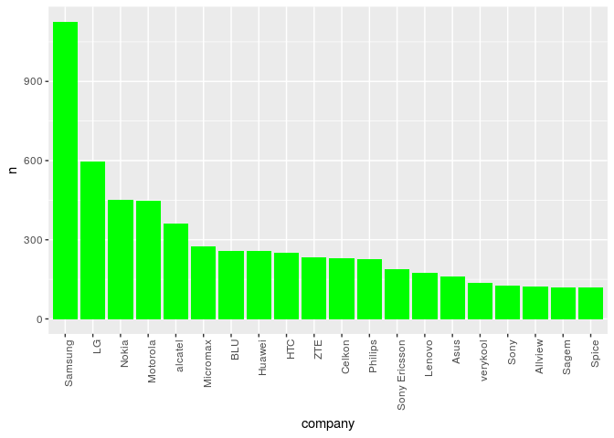

```r
mob %>% group_by(company) %>% summarise(n = n()) %>% arrange(-n) %>% slice(1:20)-> top
top$company <- factor(top$company, levels = top$company)
ggplot(top)+geom_bar(aes(x = company, y = n), stat = "identity", fill = "green")+
  theme(axis.text.x = element_text(angle = 90, hjust = 1))
```

۲. نمودار زمانی طول عرض ضخامت و کیفیت دوربین گوشی ها را بکشید و به نمودار هر یک مدل خطی اضافه کنید.

Here are the result using gruop_by, summarise. I used lm function too.

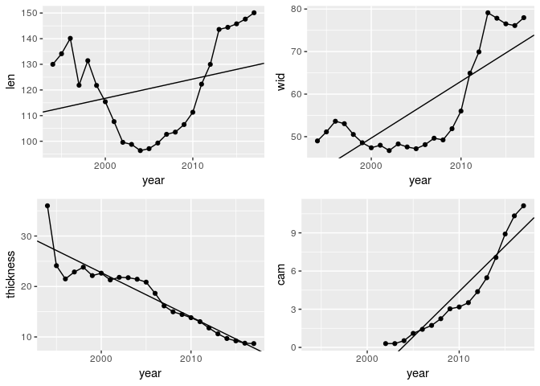

```r
mob %>% filter(!is.na(year)) %>% group_by(year) %>% summarise(len = mean(dim_length, na.rm =TRUE), wid = mean(dim_breadth, na.rm = TRUE),
                                                         thickness = mean(dim_thickness, na.rm = TRUE), cam = mean(cam_px, na.rm =TRUE)) -> mob.mean
len.lm <-lm(len~year, mob.mean)$coefficients
p1<-ggplot(mob.mean, aes(x = year, y = len)) + geom_line()+geom_point()+geom_abline(aes(intercept = len.lm[1], slope = len.lm[2] ))
wid.lm <-lm(wid~year, mob.mean)$coefficients
p2<-ggplot(mob.mean, aes(x = year, y = wid)) + geom_line()+geom_point()+geom_abline(aes(intercept = wid.lm[1], slope = wid.lm[2] ))
th.lm <-lm(thickness~year, mob.mean)$coefficients
p3<-ggplot(mob.mean, aes(x = year, y = thickness)) + geom_line()+ geom_point()+geom_abline(aes(intercept = th.lm[1], slope = th.lm[2] ))
cam.lm <-lm(cam~year, mob.mean)$coefficients
p4<-ggplot(mob.mean, aes(x = year, y = cam)) + geom_line() +geom_point()+geom_abline(aes(intercept = cam.lm[1], slope = cam.lm[2] ))
library(gridExtra)
grid.arrange(p1,p2,p3,p4, layout_matrix = rbind(c(1,2),c(3,4)))
```

We can plot all the dots too:

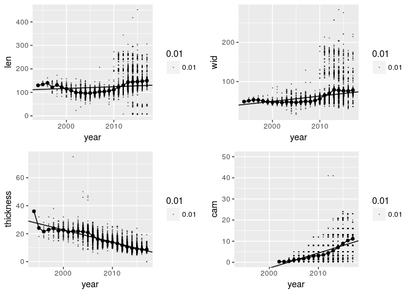

```r
mob %>% filter(!is.na(year)) %>% group_by(year) %>% summarise(len = mean(dim_length, na.rm =TRUE), wid = mean(dim_breadth, na.rm = TRUE),
                                                         thickness = mean(dim_thickness, na.rm = TRUE), cam = mean(cam_px, na.rm =TRUE)) -> mob.mean
len.lm <-lm(len~year, mob.mean)$coefficients
p1<-ggplot(mob.mean, aes(x = year, y = len)) + geom_line()+geom_point()+geom_abline(aes(intercept = len.lm[1], slope = len.lm[2] ))+
  geom_point(data = mob, aes(x = year, y = dim_length, alpha = 0.01), size = 0.01)
wid.lm <-lm(wid~year, mob.mean)$coefficients
p2<-ggplot(mob.mean, aes(x = year, y = wid)) + geom_line()+geom_point()+geom_abline(aes(intercept = wid.lm[1], slope = wid.lm[2] ))+
  geom_point(data = mob, aes(x = year, y = dim_breadth, alpha = 0.01), size = 0.01)
th.lm <-lm(thickness~year, mob.mean)$coefficients
p3<-ggplot(mob.mean, aes(x = year, y = thickness)) + geom_line()+ geom_point()+geom_abline(aes(intercept = th.lm[1], slope = th.lm[2] ))+
  geom_point(data = mob, aes(x = year, y = dim_thickness, alpha = 0.01), size = 0.01)
cam.lm <-lm(cam~year, mob.mean)$coefficients
p4<-ggplot(mob.mean, aes(x = year, y = cam)) + geom_line() +geom_point()+geom_abline(aes(intercept = cam.lm[1], slope = cam.lm[2] ))+
  geom_point(data = mob, aes(x = year, y = cam_px, alpha = 0.01), size = 0.01)
library(gridExtra)
grid.arrange(p1,p2,p3,p4, layout_matrix = rbind(c(1,2),c(3,4)))
```

***

۳. نمودار ستونی متوسط قیمت گوشی بر حسب تعداد سیم کارت و دسترسی به LTE را رسم نمایید.

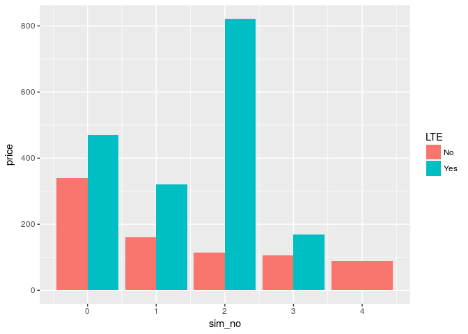

```r
mob %>% group_by(sim_no, LTE) %>% summarise(price = mean(price, na.rm = TRUE)) -> mob.pri
ggplot(mob.pri)+geom_bar(aes(x = sim_no, y = price, fill = LTE), stat = "identity", position = "dodge")
```

***

۴. نمودار جعبه ایی ضحامت گوشی هایی که در سال ۲۰۱۷ معرفی شده اند را برحسب اینکه کمیت جک هدفون رسم نمایید

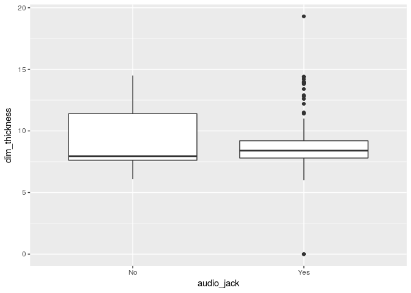

```r
ggplot(mob %>% filter(year == "2017"))+geom_boxplot(aes(x = audio_jack, y = dim_thickness), na.rm = TRUE)
```

۵. مفهوم ppi را در گوشی های موبایل محاسبه و هیستوگرام آن را رسم نمایید. همچنین نمودار سالانه متوسط این کمیت را بکشید. کدام گوشی بیشترین ppi را دارد؟

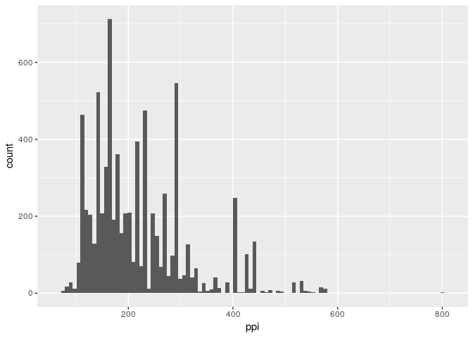

```r
#histogram ppi
mob %>% mutate(ppi = sqrt(px_row^2+px_col^2)/display_size) %>% select(device, year,  ppi) %>% .[complete.cases(.$ppi),]-> mob.ppi
#plot per year
mob.ppi %>% group_by(year) %>% summarise(ppi_mean = mean(ppi)) %>% .[complete.cases(.$year),]-> mob.ppi.mean
ggplot(mob.ppi)+geom_histogram(aes(x = ppi), bins = 100)
```

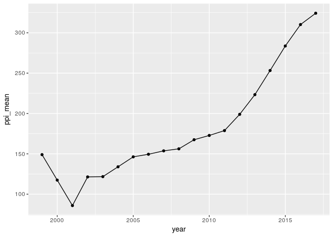

```r
ggplot(mob.ppi.mean, aes(x = year, y = ppi_mean))+geom_point()+geom_line()
```

```r
#phone with most ppi
mob.ppi %>% arrange(-ppi)%>% slice(1)
```

```
## # A tibble: 1 x 3
##   device             year   ppi
##   <fct>             <int> <dbl>
## 1 Xperia XZ Premium  2017   807
```

۶. در گذشته به بعضی از مدل های گوشی نوکیا **گوشکوب** گفته می شد. سعی کنید برای این مفهوم کمیتی مناسب تعریف کنید . ده گوشکوب برتر را پیدا کرده و نمودار گوشکوبیت آن را رسم نمایید.

I think we have two good measurements for “gooshkoob”, the density and the thickness of the phone. To find how absurd the thickness or density of a phone is we can just compute how many standard deviations it is away from the mean of that parameter. So
$$\frac{thickness - mean(thickness)}{sd(thickness)}+\frac{density - mean(density)}{sd(density)}$$
is a good criterion for being a gooshkoob.

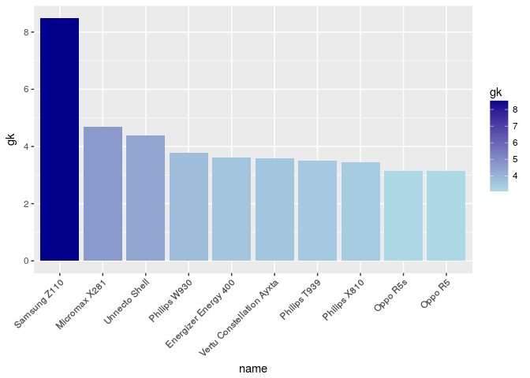

```r
mob%>% filter(display_size>2 & display_size<7)%>% select(company, device, dim_length, dim_breadth, dim_thickness, weight) %>% .[complete.cases(.),] %>%
  mutate(dens = weight/(dim_length*dim_breadth*dim_thickness*1e-3)) -> mob.dens
mob.dens %>% filter(dens < Inf) -> mob.dens
dens.mu<-mean(mob.dens$dens)
dens.sd<-sd(mob.dens$dens)
mob.dens %>% mutate(dens.gk = (dens - dens.mu)/dens.sd) -> mob.gk
thick.mu<-mean(mob.dens$dim_thickness)
thick.sd<-sd(mob.dens$dim_thickness)
mob.gk%>% mutate(thick.gk = (dim_thickness - thick.mu)/thick.sd)->mob.gk
mob.gk %>% mutate(gk = thick.gk + dens.gk)->mob.gk
mob.gk %>% arrange(-gk) %>% select(company, device, dens, gk)%>% slice(1:10) -> mob.gk
mob.gk %>% mutate(name = paste(company, device)) %>% select(name, gk)-> mob.gk
mob.gk$name <- factor(mob.gk$name, levels = mob.gk$name)
mob.gk %>% ggplot()+geom_col(aes(x = name, y = gk, fill = gk)) + scale_fill_gradient(low="lightblue", high="darkblue")+
  theme(axis.text.x = element_text(angle = 45, hjust = 1))
```

۷. آیا تلفن همراهی وجود دارد که در آب غرق نشود؟ اگر جواب بله هست تمام گوشی های که این خاصیت را دارند بیابید. با کشیدن یک نمودار به این سوال پاسخ دهید.

Density is
$$\frac{weight}{width\times height \times thickness}$$
. If it is under 1 so the phone can stand on water. I drawn a plot of the densitues of the phones and the ones under 1 so we can have a sense of how much is the portion of this phones.

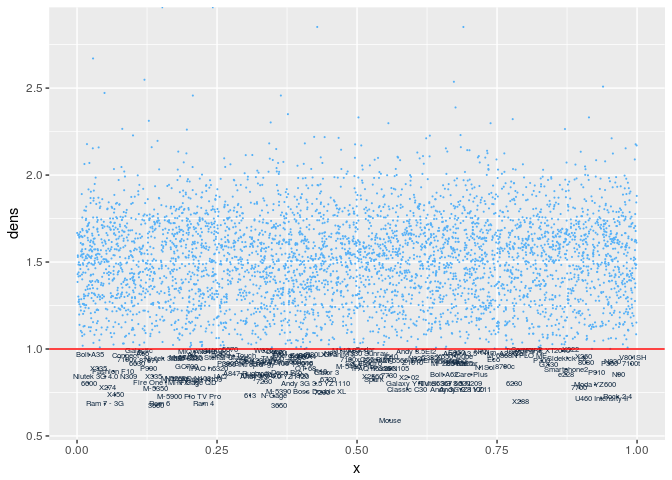

```r
mob %>% filter(display_size < 6 & display_size > 2) -> mobi
mobi%>% select(device, dim_length, dim_breadth, dim_thickness, weight) %>% .[complete.cases(.),] %>%
  mutate(dens = weight/(dim_length*dim_breadth*dim_thickness*1e-3)) -> mob.dens
x<-runif(nrow(mob.dens))
ggplot(mob.dens, aes(x = x, y = dens, color = ifelse(dens < 1,3,4), label = ifelse(dens < 1,as.character(device),"")))+guides(color = FALSE)+
  geom_point(size = 0.1)+geom_text(size = 2) + geom_abline(slope = 0, intercept =  1, color = "red")
```

```r
mob.dens %>% filter(dens < 1)
```

```
##                     device dim_length dim_breadth dim_thickness weight
## 1                     2040      123.4        51.5          12.4   77.9
## 2                     E850      102.0        54.0          20.0  108.0
## 3                    8707v      110.0        69.5          19.5  139.0
## 4                    8700c      110.0        69.5          19.5  134.0
## 5                    7100x      114.0        56.0          20.0  120.0
## 6                    7100t      119.0        58.0          19.0  120.0
## 7                    7100v      114.0        56.0          20.0  120.0
## 8                     7290      113.0        74.5          22.0  139.0
## 9                     7730      121.0        77.0          18.0  142.0
## 10                    7230      113.0        74.0          20.0  136.0
## 11                    6720      121.0        77.0          18.0  138.0
## 12                    6230      113.0        75.0          20.0  136.0
## 13                Deco Pro      108.5        64.0          12.5   75.0
## 14                    Deco      103.0        57.6          12.5   73.0
```

[output cut: 293 more lines]

۸. نمودار پراکنش حجم ذخیره سازی باطری و وزن را رسم نمایید. میزان همبستگی بین این دو کمیت را محاسبه کنید.

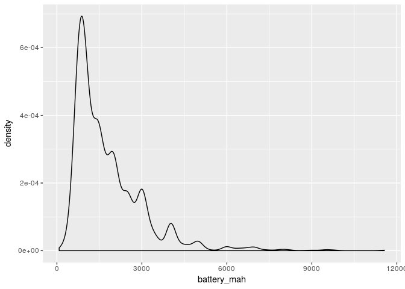

```r
ggplot(mob %>% .[complete.cases(.$battery_mah),], aes(x = battery_mah))+geom_density()
```

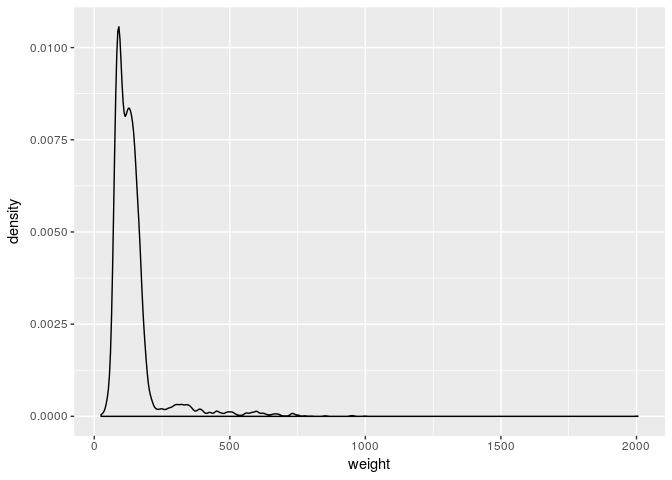

```r
ggplot(mob %>% .[complete.cases(.$weight),], aes(x = weight))+geom_density()
```

```r
mob %>% select(battery_mah, weight) %>% .[complete.cases(.),] -> mob.cor
```

the corelation is(It is so high which is logical, battery is the heaviest part in most phones):

```r
cor(mob.cor$battery_mah, mob.cor$weight)
```

```
## [1] 0.8086273
```

۹. قیمت پرچمداران یک برند خاص مثلا سامسونگ را بیابید و نمودار قیمت زمان و نام مدل را رسم نمایید.

```r
mob %>% filter(company == "Samsung", display_size<7)%>% select(price, year) %>% .[complete.cases(.),] %>% group_by(year) %>% summarise(mu = mean(price), sd = sd(price))-> sam.price
mob %>% filter(company == "Samsung", display_size<7) -> sam
full_join(sam, sam.price) -> mob.sam.price
```

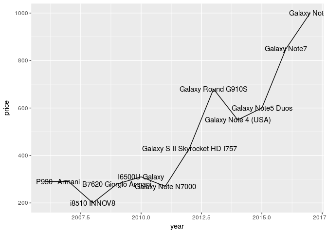

```r
mob.sam.price %>%  filter((price > mu + sd) & (price < mu + 4*sd)) -> flag.candidates
flag.candidates %>% group_by(year) %>% select(device, price, year) %>% arrange(-price)%>% slice(1) %>% ungroup() -> flag.price
ggplot(flag.price, aes(x = year, y = price))+geom_line() + geom_text(aes(label = device))
```

```r
#ggplot(.) + geom_density(aes(x = price))
```

۱۰. سه نمودار جالب رسم کنید و توضیح دهید چرا از نظر شما جالب است؟

## Number of Phones produces per year by companies

We can see the number of phones companies produce in each year and we can see their strategies. For examle Samsung was making lot’s of phones but this company stopped this and decrease the diversity of their phones(So maybe they can focus on better products). It seems other companies (apple not included) make this decision to decrease number of products.

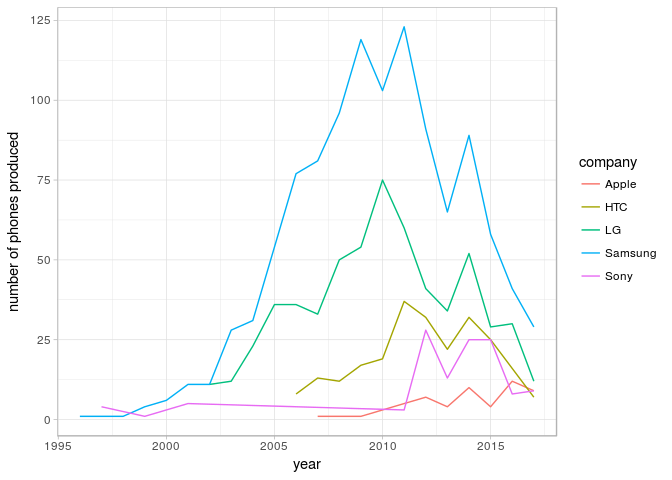

```r
cnames <- c("Apple", "Samsung", "Sony", "HTC", "LG")
mob %>%filter(company %in% cnames) -> rivals
rivals %>%  group_by(company, year) %>% summarise(n = n()) -> comp.year
ggplot(comp.year, aes(x = year, y = n, color = as.factor(company)))+geom_line()+theme_light()+labs(color = "company", y= "number of phones produced")
```

## Plot Average price for camera_px = 12 per year

It is the average price for getting a phone with a high quality camera. We see the price is going up.

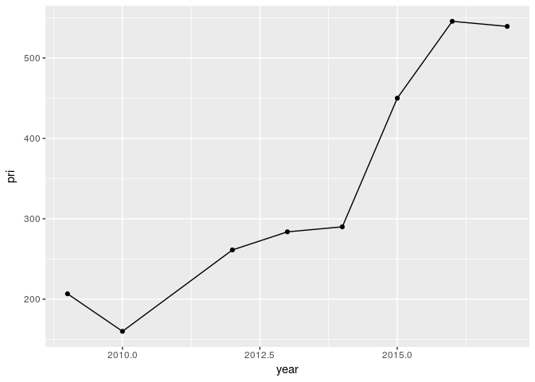

```r
mob %>% .[complete.cases(.$price),] %>%filter(price < 1500)%>%.[complete.cases(.$year),] %>% .[complete.cases(.$cam_px),] %>%
   filter(cam_px>10 & cam_px<13)%>% group_by(year) %>% summarise(pri = mean(price))-> cam.pri
ggplot(cam.pri, aes(x = year, y = pri))+geom_line()+geom_point()
```

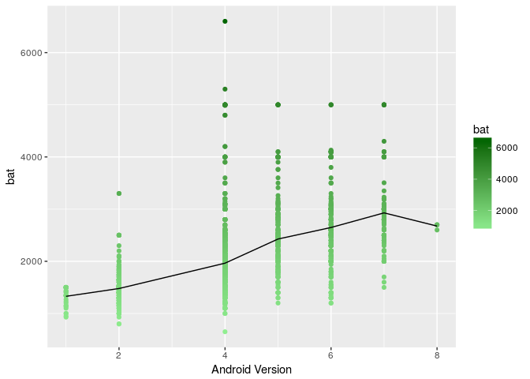

```r
mob %>% mutate(os_type = sub(" ", "", os_type))%>% filter(os_type == "Android" & display_size<5.5) %>% select(os, bat =  battery_mah)%>% mutate(os =sub("Android+[[:space:]]+", "", .$os)) %>% mutate(os = substr(.$os, 1, 1)) -> bat.os
bat.os %>% mutate(os =sub("[A-Za-z]", "", .$os)) %>% mutate(os = as.numeric(os)) ->> bat.os
bat.os %>% .[complete.cases(.),]->bat.os
bat.os %>% group_by(os) %>% summarise(bat = mean(bat)) -> bat.mean
ggplot(bat.os)+geom_point(aes(x = os, y = bat, color = bat))+scale_color_gradient(low = "lightgreen", high = "darkgreen")+
  geom_line(data = bat.mean, aes(x = os, y = bat))+
  labs(x = "Android Version")
```

This plot seems intersting because I wanted to know if Android Os versions are getting better at battery management. This plot shows that they are using big batteries yet and companies are setting bigger batteries on their phones, Maybe they just want to boost the hours but I think maybe we can infer that battery management is not getting that good in Android.